# pyproject

```python
import pandas as pd
import numpy as np
from pandas import DataFrame, Series
from numpy import random
import matplotlib.pyplot as plt
from datetime import datetime
from pandas import DatetimeIndex
from matplotlib.image import imread
%matplotlib inline
```

```python
from IPython.display import display, HTML

CSS = """
.output {
    flex-direction: row;
}
"""

HTML('<style>{}</style>'.format(CSS))
```

### 대기 오염 물질과 오존, 미세먼지(PM10), 초미세먼지(PM2.5)의 상관 관계 분석

#### (1) 목적 : 각 대기 오염 물질과 오존, 미세먼지 및 초미세먼지와 상관 관계를 규명한다.

#### (2) 조사 자료 : '서울시 일별 평균 대기오염도 정보' (기간 : 2017년 6월 22일 ~ 2018년 6월 5일)

#### (3) 자료 출처 : 서울시 공공데이터

[figure not shown]

```python
img = plt.imread("C:/DIPython/project/PM.jpg")
plt.imshow(img)
plt.figure(figsize=(6,3))
plt.show()
```

##### 1. DataFrame 객체 생성

```python
df = pd.read_csv('C:/DIPython/project/new/rawdata4.csv', encoding = 'euc-kr', index_col=0, parse_dates=True)
```

```python
display(df.head())
display(len(df))
```

| Date | Site | NO2 | SO2 | CO | O3 | PM10 | PM2.5 |
| --- | --- | --- | --- | --- | --- | --- | --- |
| 2017-06-22 | gangnam | 0.018 | 0.004 | 0.3 | 0.031 | 45.0 | 28.0 |
| 2017-06-23 | gangnam | 0.037 | 0.005 | 0.4 | 0.029 | 40.0 | 18.0 |
| 2017-06-24 | gangnam | 0.042 | 0.006 | 0.4 | 0.017 | 40.0 | 16.0 |
| 2017-06-25 | gangnam | 0.025 | 0.005 | 0.4 | 0.029 | 37.0 | 23.0 |
| 2017-06-26 | gangnam | 0.024 | 0.004 | 0.4 | 0.024 | 29.0 | 17.0 |

```
7524
```

##### Null값 보정 --> 각 column 농도의 평균값으로 보정

```python
mean1 = df['NO2'].mean()
mean2 = df['SO2'].mean()
mean3 = df['CO'].mean()
mean4 = df['O3'].mean()
mean5 = df['PM10'].mean()
mean6 = df['PM2.5'].mean()
```

```python
df.fillna({'NO2':mean1,'SO2':mean2,'CO': mean3, 'O3':mean4,'PM10':mean5,'PM2.5': mean6}, inplace=True)
df.isnull().sum()
```

```
Site     0
NO2      0
SO2      0
CO       0
O3       0
PM10     0
PM2.5    0
dtype: int64
```

##### 2. 서울시 각 오염물질들과 오존, 미세먼지(PM10), 초미세먼지(PM2.5)간의 상관관계 분석

```python
df.corr()
```

|  | NO2 | SO2 | CO | O3 | PM10 | PM2.5 |
| --- | --- | --- | --- | --- | --- | --- |
| NO2 | 1.000000 | 0.414990 | 0.740259 | -0.500264 | 0.597971 | 0.616178 |
| SO2 | 0.414990 | 1.000000 | 0.413436 | -0.276946 | 0.438938 | 0.413718 |
| CO | 0.740259 | 0.413436 | 1.000000 | -0.408060 | 0.640009 | 0.660374 |
| O3 | -0.500264 | -0.276946 | -0.408060 | 1.000000 | -0.139158 | -0.139952 |
| PM10 | 0.597971 | 0.438938 | 0.640009 | -0.139158 | 1.000000 | 0.900279 |
| PM2.5 | 0.616178 | 0.413718 | 0.660374 | -0.139952 | 0.900279 | 1.000000 |

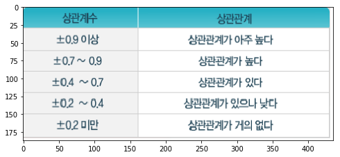

```python
img = plt.imread("C:/DIPython/project/R.png")
plt.imshow(img)
plt.figure(figsize=(7,4))
plt.show()
```

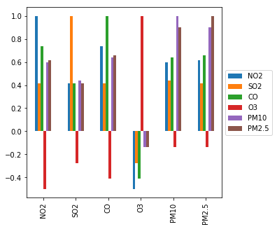

```python
df.corr().plot(kind='bar', figsize=(5,5))
plt.legend(loc='center left', bbox_to_anchor=(1, 0.5))
plt.show()
```

#### 1) 일산화탄소(CO)와 미세먼지(PM10), 초미세먼지(PM2.5)간의 상관관계

```python
R1 = df['CO'].corr(df['PM2.5'])
R2 = df['CO'].corr(df['PM10'])
display(R1, R2)
```

```
0.660374482074459
```

```
0.6400087460939
```

###### - 결론: 일산화탄소(CO)와 미세먼지(PM10), 초미세먼지(PM2.5)간에는 양의 상관관계가 있다.

#### 2) 질소산화물(NO2)과 미세먼지(PM10), 초미세먼지(PM2.5)간의 상관관계

```python
R1 = df['NO2'].corr(df['PM2.5'])
R2 = df['NO2'].corr(df['PM10'])
display(R1, R2)
```

```
0.616177994317868
```

```
0.59797126630924
```

###### - 결론: 질소산화물(NO2)과 미세먼지(PM10), 초미세먼지(PM2.5)간에는 양의 상관관계가 있다.

#### 3) 황산화물(SO2)과 미세먼지(PM10), 초미세먼지(PM2.5)간의 상관관계

```python
R1 = df['SO2'].corr(df['PM2.5'])
R2 = df['SO2'].corr(df['PM10'])
display(R1, R2)
```

```
0.4137177264029647
```

```
0.4389376836612648
```

###### - 결론: 황산화물(SO2)과 미세먼지(PM10), 초미세먼지(PM2.5)간에는 양의 상관관계가 있다.

#### 4) 미세먼지(PM10)와 초미세먼지(PM2.5)간의 상관관계

```python
df['PM2.5'].corr(df['PM10'])
```

```
0.9002789815683637
```

###### - 결론 : 미세먼지의 농도가 높은 날은 초미세먼지의 농도도 높을 것이다.

##### 3. 시각화 : 서울시 각 오염 물질 별 농도와 미세먼지, 초미세먼지와의 농도

###### 1) 일산화탄소(CO)과 미세먼지, 초미세먼지와의 상관 관계

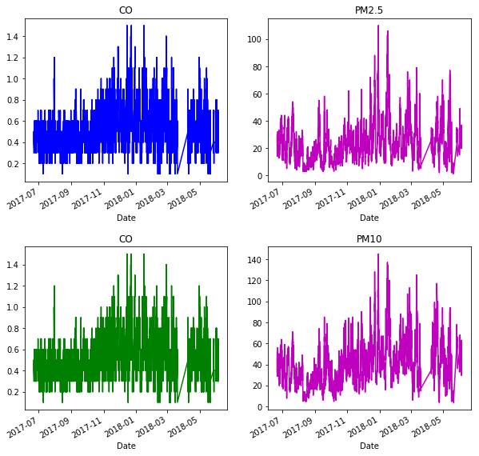

```python
fig, axes = plt.subplots(2,2, figsize=(10, 10))
df['CO'].plot(style='b-', ax = axes[0][0] )
axes[0][0].set_title("CO")
df['PM2.5'].plot(style='m-', ax = axes[0][1] )
axes[0][1].set_title("PM2.5")
df['CO'].plot(style='g-', ax = axes[1][0] )
axes[1][0].set_title("CO")
df['PM10'].plot(style='m-', ax = axes[1][1] )
axes[1][1].set_title("PM10")
plt.subplots_adjust(hspace=0.4)
plt.show()
```

###### 2) 질소산화물(NO2)과 미세먼지, 초미세먼지와의 상관 관계

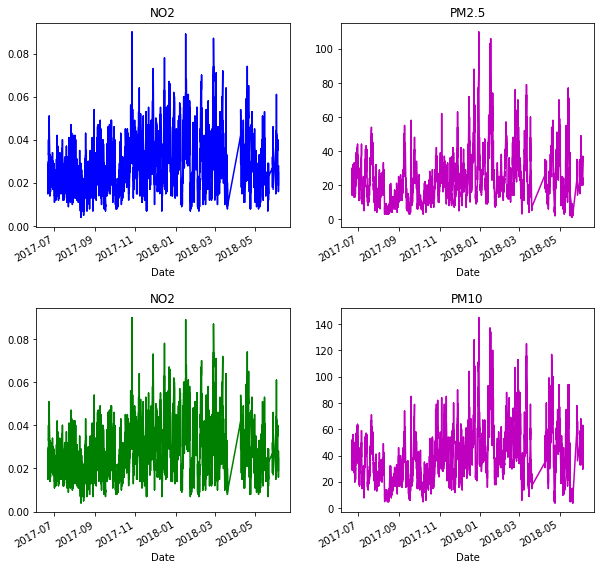

```python
fig, axes = plt.subplots(2,2, figsize=(10, 10))
df['NO2'].plot(style='b-', ax = axes[0][0] )
axes[0][0].set_title("NO2")
df['PM2.5'].plot(style='m-', ax = axes[0][1] )
axes[0][1].set_title("PM2.5")
df['NO2'].plot(style='g-', ax = axes[1][0] )
axes[1][0].set_title("NO2")
df['PM10'].plot(style='m-', ax = axes[1][1] )
axes[1][1].set_title("PM10")
plt.subplots_adjust(hspace=0.4)
plt.show()
```

###### 3) 황산화물(SO2)과 미세먼지, 초미세먼지와의 상관 관계

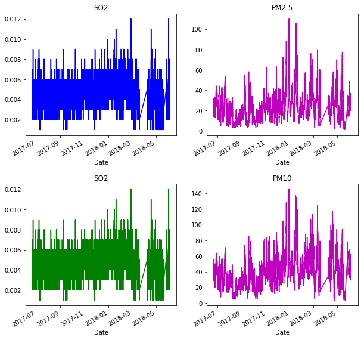

```python
fig, axes = plt.subplots(2,2, figsize=(10, 10))
df['SO2'].plot(style='b-', ax = axes[0][0] )
axes[0][0].set_title("SO2")
df['PM2.5'].plot(style='m-', ax = axes[0][1] )
axes[0][1].set_title("PM2.5")
df['SO2'].plot(style='g-', ax = axes[1][0] )
axes[1][0].set_title("SO2")
df['PM10'].plot(style='m-', ax = axes[1][1] )
axes[1][1].set_title("PM10")
plt.subplots_adjust(hspace=0.4)
plt.show()
```

###### 4) 미세먼지와 초미세먼지간의 상관 관계

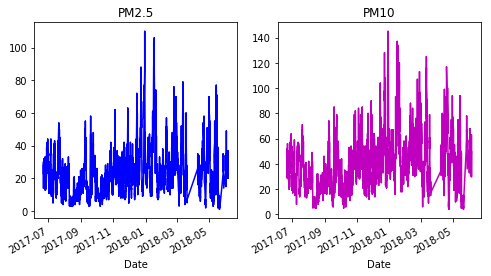

```python
fig, axes = plt.subplots(1,2, figsize=(8, 4))
df['PM2.5'].plot(style='b-', ax = axes[0])
axes[0].set_title("PM2.5")
df['PM10'].plot(style='m-', ax = axes[1])
axes[1].set_title("PM10")
plt.show()
```

```python
import scipy as sp
from scipy import stats
from scipy import polyval
from pylab import plot, title, legend, show
```

### 선형 회귀분석과 시각화

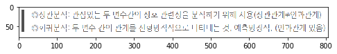

```python
img = plt.imread("C:/DIPython/project/reg.png")
plt.imshow(img)
plt.figure(figsize=(7,4))
plt.show()
```

```python
plt.rcParams["figure.figsize"] = (8,4)
```

###### 1) 일산화탄소(CO)와 미세먼지, 초미세먼지

```python
reg1 = stats.linregress(df['CO'], df['PM2.5'])
reg2 = stats.linregress(df['CO'], df['PM10'])
print(reg1)
print()
print(reg2)
```

```
LinregressResult(slope=51.72052625277583, intercept=-3.4010805034076057, rvalue=0.6603744820744589, pvalue=0.0, stderr=0.6781240849109524)

LinregressResult(slope=70.44702263604115, intercept=3.004733830722593, rvalue=0.6400087460939, pvalue=0.0, stderr=0.9751672920990853)
```

```python
reg_line1 = polyval([reg1.slope, reg1.intercept],df['CO'] )
reg_line2 = polyval([reg2.slope, reg2.intercept],df['CO'] )
```

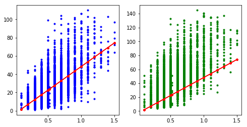

```python
fig, ax = plt.subplots(1,2)
ax[0].plot(df['CO'], df['PM2.5'], 'b.')
ax[0].plot(df['CO'], reg_line1, 'r.-')
ax[1].plot(df['CO'], df['PM10'], 'g.')
ax[1].plot(df['CO'], reg_line1, 'r.-')
plt.show()
```

###### 2) 질소산화물(NO2)과 미세먼지, 초미세먼지

```python
reg3 = stats.linregress(df['NO2'], df['PM2.5'])
reg4 = stats.linregress(df['NO2'], df['PM10'])
print(reg3)
print()
print(reg4)
```

```
LinregressResult(slope=745.6998926456063, intercept=1.8259662746300265, rvalue=0.6161779943178681, pvalue=0.0, stderr=10.990077668583996)

LinregressResult(slope=1017.0499763174976, intercept=10.08504096873455, rvalue=0.5979712663092399, pvalue=0.0, stderr=15.718400258892887)
```

```python
reg_line3 = polyval([reg3.slope, reg3.intercept],df['NO2'] )
reg_line4 = polyval([reg4.slope, reg4.intercept],df['NO2'] )
```

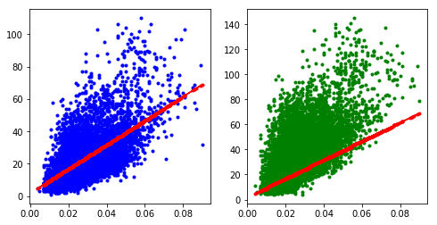

```python
fig, ax = plt.subplots(1,2)
ax[0].plot(df['NO2'], df['PM2.5'], 'b.')
ax[0].plot(df['NO2'], reg_line3, 'r.-')
ax[1].plot(df['NO2'], df['PM10'], 'g.')
ax[1].plot(df['NO2'], reg_line3, 'r.-')
plt.show()
```

###### 3) 황산화물(SO2)과 미세먼지, 초미세먼지

```python
reg5 = stats.linregress(df['SO2'], df['PM2.5'])
reg6 = stats.linregress(df['SO2'], df['PM2.5'])
print(reg5)
print()
print(reg6)
```

```
LinregressResult(slope=4191.690392607817, intercept=4.647699623541381, rvalue=0.41371772640296467, pvalue=5.13382442656338e-309, stderr=106.35383062280086)

LinregressResult(slope=4191.690392607817, intercept=4.647699623541381, rvalue=0.41371772640296467, pvalue=5.13382442656338e-309, stderr=106.35383062280086)
```

```python
reg_line5 = polyval([reg5.slope, reg5.intercept],df['SO2'] )
reg_line6 = polyval([reg6.slope, reg6.intercept],df['SO2'] )
```

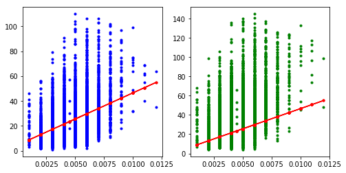

```python
fig, ax = plt.subplots(1,2)
ax[0].plot(df['SO2'], df['PM2.5'], 'b.')
ax[0].plot(df['SO2'], reg_line5, 'r.-')
ax[1].plot(df['SO2'], df['PM10'], 'g.')
ax[1].plot(df['SO2'], reg_line6, 'r.-')
plt.show()
```

### 고차 회귀분석과 시각화

```python
x = df['CO']
y = df['PM2.5']
```

```python
pf1, res1, a, b, c = sp.polyfit(x, y, 1, full = True)
print('1차항 기울기와 절편 : %s' % pf2)
print('1차항 잔차 : %s' % res2)
```

[output not shown]

```python
p1 = sp.poly1d(pf1)
print(p1)
```

```
51.72 x - 3.401
```

```python
pf2, res2, a, b, c = sp.polyfit(x, y, 2, full = True)
print('2차항 기울기와 절편 : %s' % pf2)
print('2차항 잔차 : %s' % res2)
```

```
2차항 기울기와 절편 : [ 9.98450741 39.15153461  0.0727995 ]
2차항 잔차 : [939017.50487145]
```

```python
p2 = sp.poly1d(pf2)
print(p2)
```

```
       2
9.985 x + 39.15 x + 0.0728
```

```python
pf3, res3, a, b, c = sp.polyfit(x, y, 3, full = True)
print('3차항 기울기와 절편 : %s' % pf2)
print('3차항 잔차 : %s' % res2)
```

[output not shown]

```python
p3 = sp.poly1d(pf3)
print(p3)
```

```
        3         2
-17.63 x + 47.31 x + 15.75 x + 4.411
```

```python
colors = ['g','r','b']
linestyles = ['-','-.','--']

def plot_model(x, y, models=None):
    plt.scatter(x, y)
    plt.axis([0,1.6,0,120])
    if models:
        mx = sp.linspace(0,150,num=100)
        for model, color, line in zip(models, colors, linestyles):
            plt.plot(mx, model(mx),linestyle=line, c=color)
        plt.legend(["d=%i" % m.order for m in models], loc='upper left')
    plt.show()
```

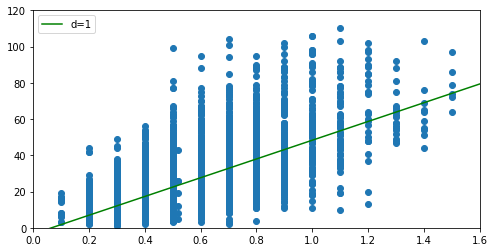

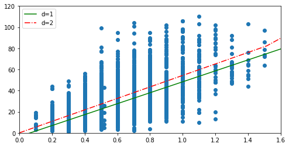

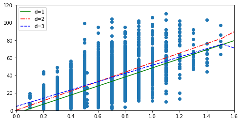

```python
plot_model(x,y,[p1])
plot_model(x,y,[p1, p2])
plot_model(x,y,[p1,p2,p3])
```